# Podstawowe predykaty geometryczne, przeprowadzanie testów, wizualizacja i opracowanie wyników

```python
import numpy as np
import pandas as pd
import matplotlib.pyplot as plt
plt.rcParams.update({'figure.max_open_warning': 0})

from bitalg.tests.test1 import Test
from bitalg.visualizer.main import Visualizer
```

# Przydatne funkcje

```python
def draw_points(points):
    vis = Visualizer()
    vis.add_point(points, s=10, color="green")
    vis.show()
```

```python
def draw_line(points_left, points_mid, points_right, title=None):
    vis = Visualizer()
    if title is not None:
        vis.add_title(title)
    vis.add_line(((-1.0, 0.0), (1.0, 0.1)), color="red")
    vis.add_point(points_left, s=10, color=["green"])
    vis.add_point(points_mid, s=10, color=["purple"])
    vis.add_point(points_right, s=10, color=["orange"])
    vis.show()

    return vis
```

```python
def draw_example():
    vis = Visualizer()
    vis.add_line(((0, 2), (10, 7)))
    vis.add_point((4, 4), s=10, color="green")
    vis.add_point((6, 6), s=10, color="red")
    vis.add_point((7, 4), s=10, color="purple")
    vis.show()
```

### Wprowadzenie

Celem ćwiczenia jest określenie po której stronie prostej znajduje się punkt.

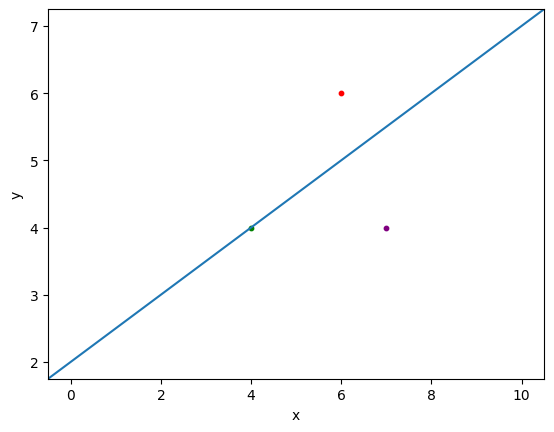

```python
draw_example()
```

Do tego celu potrzebujesz wygenerować zbiory punktów testowych.

# Generowanie losowych punktów na płaszczyźnie

Uzupełnij funkcję `generate_uniform_points` (Aby generować losowo liczby rzeczywiste bardzo przydatna może okazać się jakaś funckja biblioteczna)

```python
def generate_uniform_points(left, right, n=10**5):
    """
    Funkcja generuje równomiernie n punktów na kwadwratowym obszarze od left do right (jednakowo na osi y) o współrzędnych rzeczywistych
    :param left: lewy kraniec przedziału
    :param right: prawy kraniec przedziału
    :param n: ilość generowanych punktów
    :return: tablica punktów w postaci krotek współrzędnych np. [(x1, y1), (x2, y2), ... (xn, yn)]
    """
    uniform_points = []
    for i in range(n):
        x_i, y_i = np.random.uniform(left, right), np.random.uniform(left, right)
        uniform_points.append((x_i, y_i))
    return uniform_points
```

Ćw. Wygeneruj $10^5$ losowych punktów w przestrzeni 2D o współrzędnych z przedziału $x, y \in \left[-1000,1000\right]^{2}$.

```python
points_a = generate_uniform_points(-1000, 1000, 10**5)
```

Zwizualizuj wygenerowane punkty

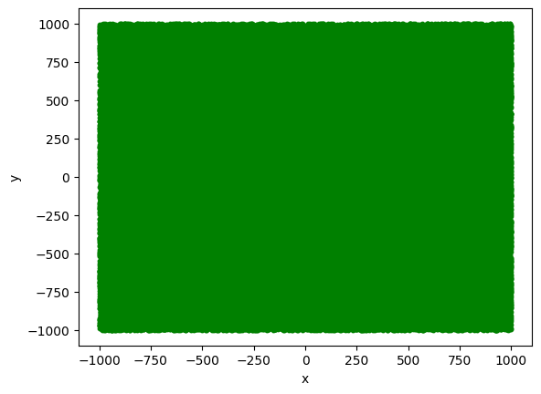

```python
draw_points(points_a)
```

Ćw. Wygeneruj $10^5$ losowych punktów w przestrzeni 2D o współrzędnych z przedziału $ x, y \in \left[-10^{14},10^{14}\right]^{2}$. Uzupełnij funkcję `generate_big_num_of_points_2D`. Sprawdź, czy różni się wizualizalnie wynik tego ćwiczenia z poprzednim.

```python
points_b = generate_uniform_points(-(10**14), 10**14, 10**5)
```

Zwizualizuj wygenerowane punkty.

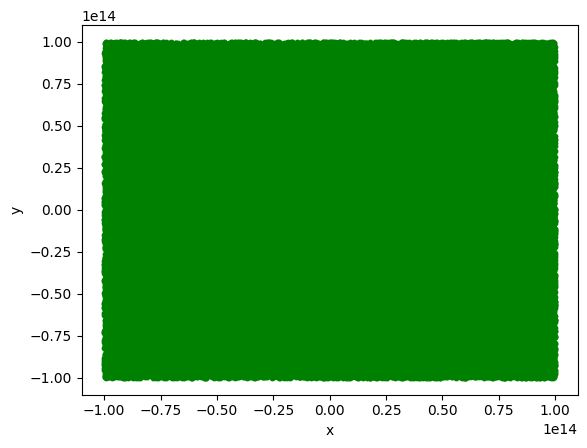

```python
draw_points(points_b)
```

Uzupełnij funkcję `generate_circle_points`

Zastanów się w sposób generować punkty jednostajnie na okręgu.

```python
def generate_circle_points(O, R, n=100):
    """
    Funkcja generuje jednostajnie n punktów na okręgu o środku O i promieniu R
    :param O: krotka współrzędnych x, y określająca środek okręgu
    :param R: promień okręgu
    :param n: ilość generowanych punktów
    :return: tablica punktów w postaci krotek współrzędnych
    """
    circle_points = []
    for i in range(n):
        phi = 2 * np.pi * np.random.sample()
        x_i, y_i = R * np.cos(phi), R * np.sin(phi)
        circle_points.append((x_i + O[0], y_i + O[1]))
    return circle_points
```

Ćw. Wygeneruj $ 1000$ losowych punktów w przestrzeni 2D leżących na okręgu o środku $ O = (0,0)$ i promieniu $ R = 100$.

Uzupełnij funkcję `generate_points_on_circle_2D`.

```python
points_c = generate_circle_points((0, 0), 100, 1000)
```

Zwizualizuj wygenerowane punkty.

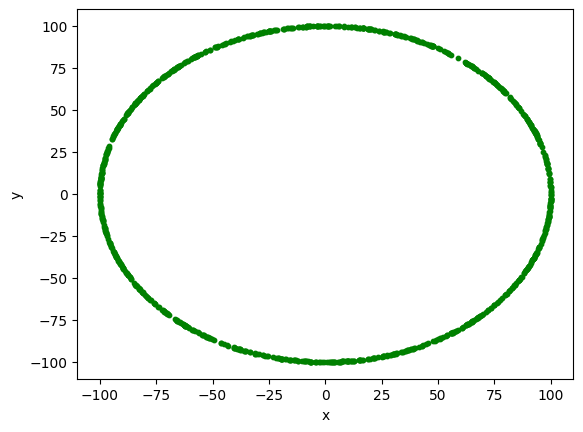

```python
draw_points(points_c)
```

Uzupełnij funkcję `generate_collinear_points`.

```python
def generate_collinear_points(a, b, n=100):
    """
    Funkcja generuje równomiernie n współliniowych punktów leżących na prostej ab pomiędzy punktami a i b
    :param a: krotka współrzędnych oznaczająca początek wektora tworzącego prostą
    :param b: krotka współrzędnych oznaczająca koniec wektora tworzącego prostą
    :param n: ilość generowanych punktów
    :return: tablica punktów w postaci krotek współrzędnych
    """
    collinear_points = []
    slope = (b[1] - a[1]) / (b[0] - a[0])
    intercept = a[1] - slope * a[0]
    for i in range(n):
        x_i = np.random.uniform(a[0], b[0])
        y_i = slope * x_i + intercept
        collinear_points.append((x_i, y_i))
    return collinear_points
```

```python
points_d = generate_collinear_points((-1.0, 0.0), (1.0, 0.1), 1000)
```

Zwizualizuj wygenerowane punkty.

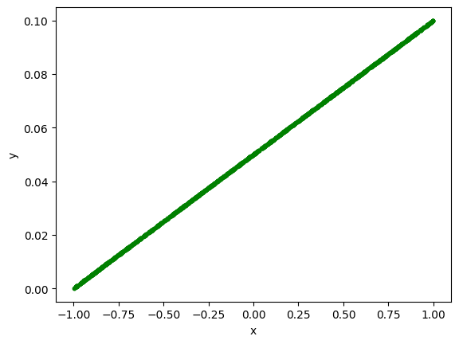

```python
draw_points(points_d)
```

Przeprowadź test poprawności powyższych funkcji

```python
Test().runtest(
    1, generate_uniform_points, generate_circle_points, generate_collinear_points
)
```

```
Lab 1, task 1:
	Test 1: Passed
	Test 2: Passed
	Test 3: Passed
	Test 4: Passed
Result: 4/4
Time: 0.646s
```

# Po której stronie prostej znajduje się punkt?

Prostym sposobem do obliczenia, po której stronie prostej znajduje się punkt jest obliczenie iloczynu wektorowego $\overrightarrow{ab} \times \overrightarrow{ac}$, gdzie $ c = (x,y)$ jest punktem, dla którego poszukujemy wiadomości o lokalizacji względem prostej przechodzącej przez punkty $ a$ i $ b$. Metoda ta jest równoznaczna z obliczeniem wyznacznika macierzy $ 2\times2$:

$$ (1)\det(a, b, c)= \begin{vmatrix} a_{x} - c_{x} & a_{y} - c_{y} \\ b_{x} - c_{x} & b_{y} - c_{y} \end{vmatrix} $$

lub wyznacznika macierzy $ 3\times3$:

$$ (2)\det(a, b, c)= \begin{vmatrix} a_{x} & a_{y} & 1 \\ b_{x} & b_{y} & 1 \\ c_{x} & c_{y} & 1 \end{vmatrix} $$

Upraszczając tą macierz przez odjęcie drugiego wiersza od trzeciego i odjęcie pierwszego wiersza od drugiego otrzymamy:

$$ \det(a, b, c) = \begin{vmatrix} a_{x} & a_{y} & 1 \\ b_{x} - a_{x} & b_{y} - a_{y} & 0 \\ c_{x} - b_{x} & c_{y} - b_{y} & 0 \end{vmatrix} = (b_{x} - a_{x})(c_{y} - b_{y}) - (b_{y} - a_{y})(c_{x} - b_{x}) $$

Jest to wzór, z który opisuje pole równoległoboku mającego boki $ ab$ oraz $ ac$ (Dowód dlaczego tak jest, do zrobienia w domu)  
Dlaczego wiemy, że po obliczeniu wskaźnika podanego powyżej będziemy wiedzieć, po której stornie prostej znajduje się punkt?

**Dowód**:

Załóżmy, że mamy dane trzy punkty w przestrzeni 2-wymiarowej $A, B$ oraz $C$. Znajdujemy prostą przechodzącą przez punkty $A$ i $B$. Następnie obliczamy $C_{y}$ przy danym $C_{x}$ i sprawdzamy czy punkt leży nad czy pod prostą. Współczynnik nachylenia prostej jest nastepujący:

$$a = \frac{B_{y} - A_{y}}{B_{x} - A_{x}} $$ Natomiast współczynnik $b$ wynosi:

$$b = B_{y} - \frac{(B_{y} - A_{y})B_{x}}{B_{x} - A_{x}} $$

Po wpisaniu do równania $y = ax + b$ wyliczonego nachylenia prostej, współczynnika $b$ oraz zmiennej $C_{x}$ otrzymujemy:

$$y = \left(\frac{B_{y} - A_{y}}{B_{x} - A_{x}}\right)C_{x}+ \left(B_{y} - \frac{(B_{y} - A_{y})B_{x}}{B_{x} - A_{x}}\right) $$

Otzymujemy punkt $C$ po lewej stronie prostej jeżeli $C_{y} - y > 0$, po prawej jeżeli $C_{y} - y < 0$, a punkt $C$ leżący na prostej, jeżeli $C_{y} - y = 0$. Przekształcimy powyższe równanie dla $C_{y} - y > 0$:

$$C_{y} - y > 0$$ $$C_{y} - \left(\frac{B_{y} - A_{y}}{B_{x} - A_{x}}\right)C_{x} - \left(B_{y} - \frac{(B_{y} - A_{y})B_{x}}{B_{x} - A_{x}}\right) > 0$$ $$C_{y}(B_{x} - A_{x}) - C_{x}(B_{y} - A_{y}) - B_{y}(B_{x} - A_{x}) + B_{x}(B_{y} - A_{y}) > 0$$ $$(C_{y} - B_{y})(B_{x} - A_{x}) + (B_{x} - C_{x})(B_{y} - A_{y}) > 0$$ $$(C_{y} - B_{y})(B_{x} - A_{x}) - (C_{x} - B_{x})(B_{y} - A_{y}) > 0$$

Zatem widzimy, że ostatnie równie jest takie same co przy równaniu wyznacznika macierzy $3\times3$. Niejawnie założyliśmy tutaj, że $B_{x}$ jest wieksze od $A_{x}$ , jeżeli byłoby odwrotnie zmieniłby się tylko znak nierówności na przeciwny. W naszym przypadku pokazaliśmy, że $C$ znajduje się po lewej stronie prostej jeżeli wyznacznik jest dodatni oraz po prawej stronie prostej, jeżeli wyznacznik jest ujemny. $Q.E.D$

Kolejnym zadaniem będzie zaimplementowanie własnych wyznaczników $(1)$ oraz $(2)$ i porówanie ich szybkości działania z wyznacznikami bibliotecznymi w testowaniu dla różnych zbiorów punktów. Co dodatkowo chcemy sprawdzić, czy wszystkie wyznaczniki podobnie kwalifikują podział względem danej lini.

Uzupełnij funkcje `mat_det_3x3`

```python
def mat_det_3x3(a, b, c):
    """
    Obliczanie wyznacznika macierzy 3x3 bez użycia funkcji bibliotecznych
    :param a: krotka współrzędnych (x, y) pierwszego punktu tworzącego naszą prostą
    :param b: krotka współrzędnych (x, y) drugiego punktu tworzącego naszą prostą
    :param c: krotka współrzędnych (x, y) punktu, którego położenie względem prostej chcemy znaleźć
    :return: wartość wyznacznika macierzy
    """
    a_x, a_y = a
    b_x, b_y = b
    c_x, c_y = c
    return (b_x - a_x) * (c_y - b_y) - (b_y - a_y) * (c_x - b_x)
```

Uzupełnij funkcję `mat_det_3x3_lib`, ale tym razem wykorzystaj dowolną funckję biblioteczną do obliczenia wyznacznika

```python
def mat_det_3x3_lib(a, b, c):
    """
    Obliczanie wyznacznika macierzy 3x3 z użyciem funkcji bibliotecznych
    :param a: krotka współrzędnych (x, y) pierwszego punktu tworzącego naszą prostą
    :param b: krotka współrzędnych (x, y) drugiego punktu tworzącego naszą prostą
    :param c: krotka współrzędnych (x, y) punktu, którego położenie względem prostej chcemy znaleźć
    :return: wartość wyznacznika macierzy
    """
    a_x, a_y = a
    b_x, b_y = b
    c_x, c_y = c
    matrix = np.array(
        [
            [a_x, a_y, 1],
            [b_x, b_y, 1],
            [c_x, c_y, 1],
        ]
    )
    return np.linalg.det(matrix)
```

Uzupełnij funkcje `mat_det_2x2`

```python
def mat_det_2x2(a, b, c):
    """
    Obliczanie wyznacznika macierzy 2x2 bez użycia funkcji bibliotecznych
    :param a: krotka współrzędnych (x, y) pierwszego punktu tworzącego naszą prostą
    :param b: krotka współrzędnych (x, y) drugiego punktu tworzącego naszą prostą
    :param c: krotka współrzędnych (x, y) punktu, którego położenie względem prostej chcemy znaleźć
    :return: wartość wyznacznika macierzy
    """
    a_x, a_y = a
    b_x, b_y = b
    c_x, c_y = c
    return (a_x - c_x) * (b_y - c_y) - (a_y - c_y) * (b_x - c_x)
```

Uzupełnij funkcję `mat_det_2x2_lib`, ale tym razem wykorzystaj dowolną funckję biblioteczną do obliczenia wyznacznika

```python
def mat_det_2x2_lib(a, b, c):
    """
    Obliczanie wyznacznika macierzy 2x2 z użyciem funkcji bibliotecznych
    :param a: krotka współrzędnych (x, y) pierwszego punktu tworzącego naszą prostą
    :param b: krotka współrzędnych (x, y) drugiego punktu tworzącego naszą prostą
    :param c: krotka współrzędnych (x, y) punktu, którego położenie względem prostej chcemy znaleźć
    :return: wartość wyznacznika macierzy
    """
    a_x, a_y = a
    b_x, b_y = b
    c_x, c_y = c
    matrix = np.array(
        [
            [a_x - c_x, a_y - c_y],
            [b_x - c_x, b_y - c_y],
        ]
    )
    return np.linalg.det(matrix)
```

Przetestujmy napisane powyżej funkcje.

```python
Test().runtest(2, mat_det_3x3, mat_det_2x2, mat_det_3x3_lib, mat_det_2x2_lib)
```

```
Lab 1, task 2:
	Test 1: Passed
	Test 2: Passed
Result: 2/2
Time: 0.000s
```

Ćw. Klasyfikacja punktów względem prostej - zaimplementuj funkcję `categorize_points`, która skwalifukuje punkty względem prostej wyznacznonej przez wektor $\large \overrightarrow{ab}$ (prosta przechodząca przez punkty $\large a$ oraz $\large b$.

```python
def categorize_points(points, a, b, mat_det_func, eps):
    """
    :param points: tablica punktów w postaci krotek współrzednych
    :param a: krotka współrzędnych oznaczająca początek odcinka
    :param b: krotka współrzędnych oznaczająca koniec odcinka
    :param mat_det_func: funkcja która będzie tutaj używana do obliczenia wyznacznika macierzy
    :param eps: epsilon - jak blisko wyznacznik macierzy ma być blisko zera, aby uznać punkt za leżący na prostej
    :return: 3 tablice zawierające kolejno zbiory punktów: leżące na lewo od prostej, leżące na prostej, leżące na prawo od prostek
    """
    classified_points_left = []
    classified_points_mid = []
    classified_points_right = []
    for point in points:
        det = mat_det_func(a, b, point)
        if abs(det) < eps:  # det == 0
            classified_points_mid.append(point)
        elif det > 0:
            classified_points_left.append(point)
        else:
            classified_points_right.append(point)
    return classified_points_left, classified_points_mid, classified_points_right
```

# Klasyfikacja

```python
a = (-1.0, 0.0)
b = (1.0, 0.1)
```

```python
classification_results = []
```

### Sposoby liczenia wyznacznika

```python
mat_det_funcs = [
    mat_det_3x3,
    mat_det_3x3_lib,
    mat_det_2x2,
    mat_det_2x2_lib,
]
```

### Epsilony

```python
epsilons = [
    0,
    10**-6,
    10**-12,
    10**-16,
]
```

### Dokładności

```python
float_resolutions = [
    np.float64,
    np.float32,
]
```

### Kolory

Zwizualizuj sklasyfikowane punkty. Punkty różnią się kolorami ze względu na klasyfikację: na lewo od prostej - zielone, na prostej - fioletowe, na prawo - pomarańczowe.

### Klasyfikacja zbioru a

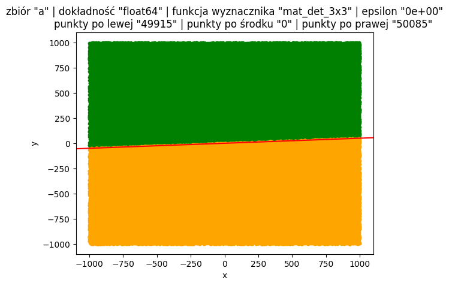

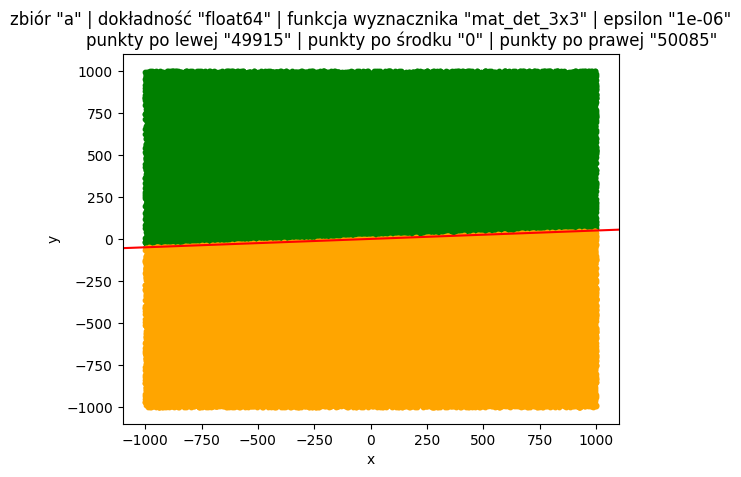

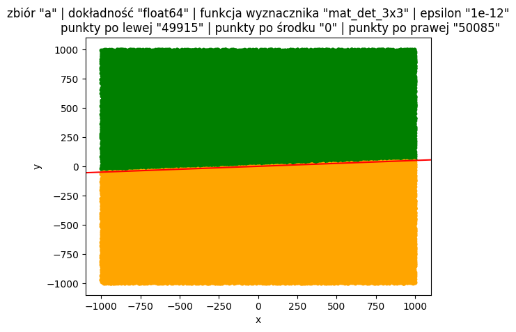

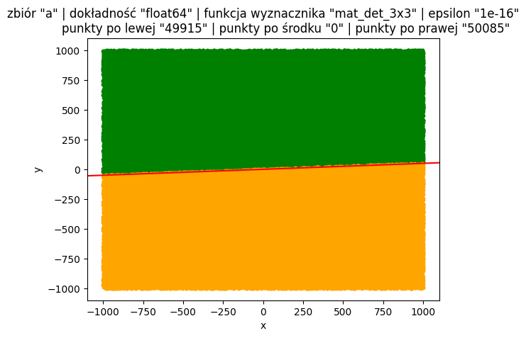

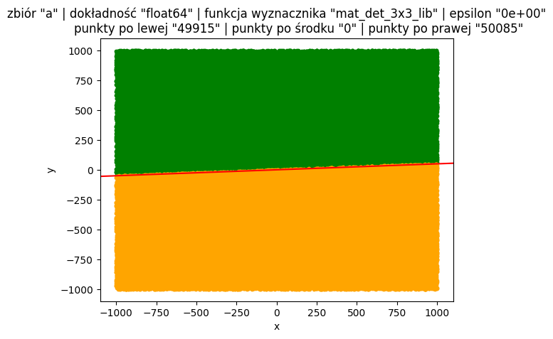

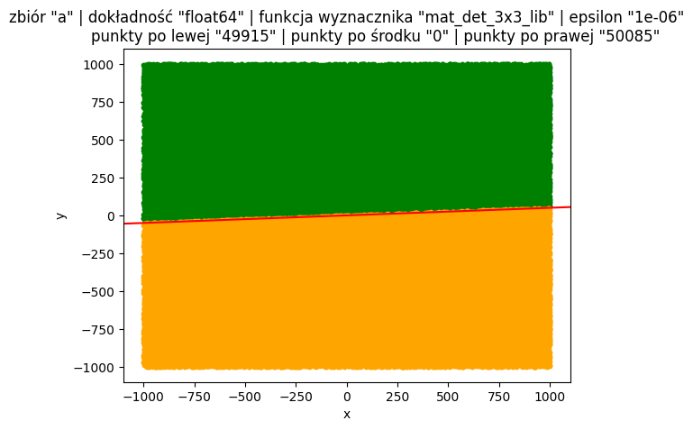

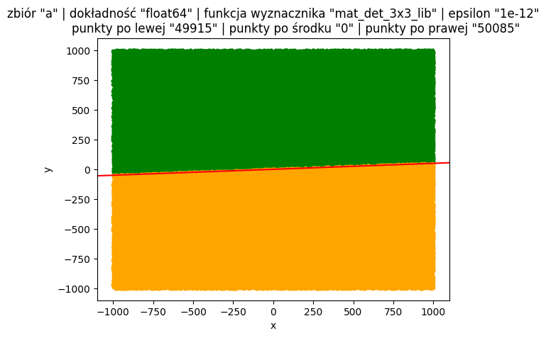

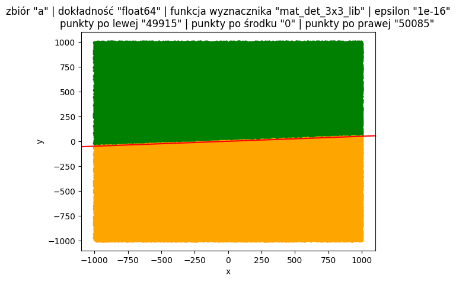

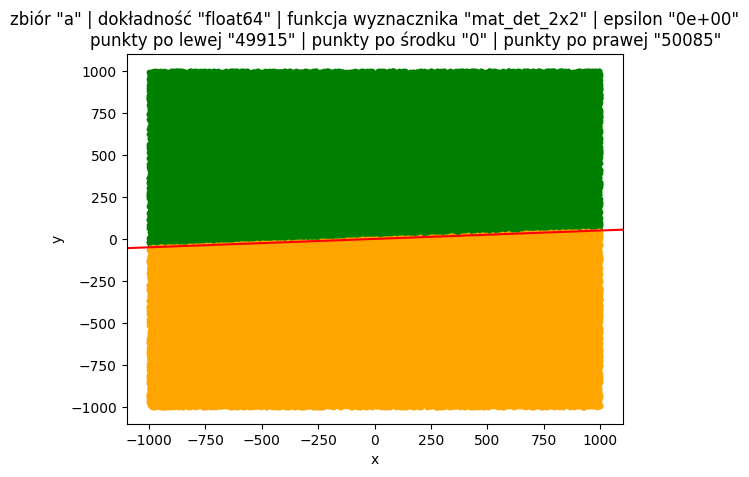

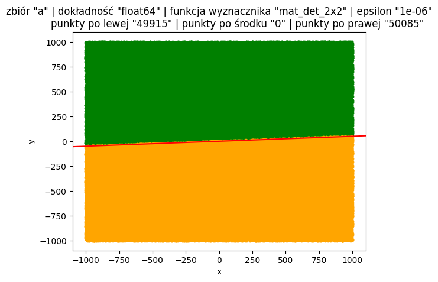

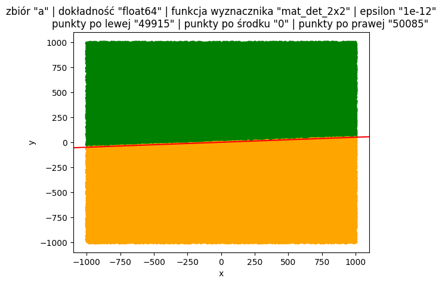

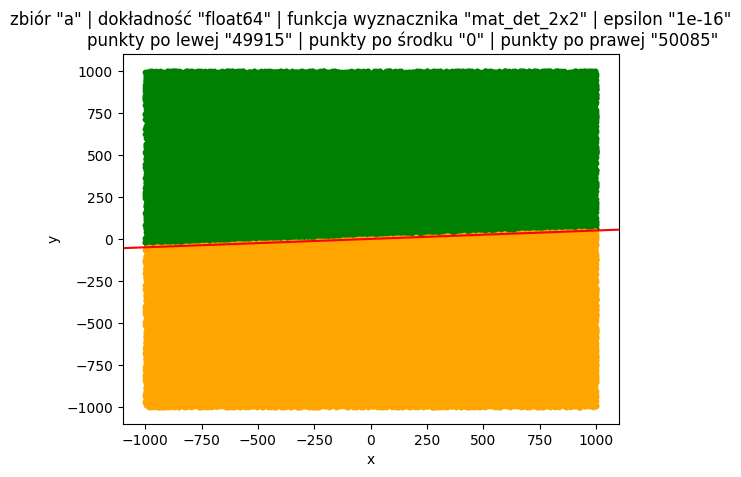

[20 more figures not shown]

```python
set_name = "a"
for float_resolution in float_resolutions:
    for mat_det_func in mat_det_funcs:
        for epsilon in epsilons:
            (
                classified_points_a_left,
                classified_points_a_mid,
                classified_points_a_right,
            ) = categorize_points(
                float_resolution(points_a), a, b, mat_det_func, epsilon
            )

            title = f"zbiór \"{set_name}\" | dokładność \"{float_resolution.__name__}\" | funkcja wyznacznika \"{mat_det_func.__name__}\" | epsilon \"{epsilon:.0e}\"\n\
            punkty po lewej \"{len(classified_points_a_left)}\" | punkty po środku \"{len(classified_points_a_mid)}\" | punkty po prawej \"{len(classified_points_a_right)}\""

            vis = draw_line(
                classified_points_a_left,
                classified_points_a_mid,
                classified_points_a_right,
                title=title
            )

            parameters = {
                "set_name": set_name,
                "float_resolution": float_resolution,
                "mat_det_func": mat_det_func,
                "epsilon": epsilon,
                "classified_points_left": classified_points_a_left,
                "classified_points_mid": classified_points_a_mid,
                "classified_points_right": classified_points_a_right,
                "visualiser": vis,
            }
            classification_results.append(parameters)
```

### Klasyfikacja zbioru b

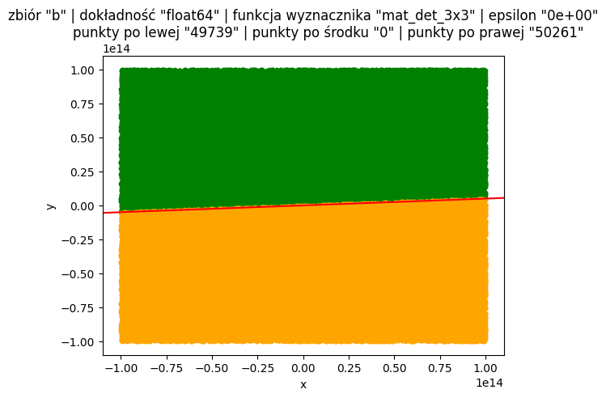

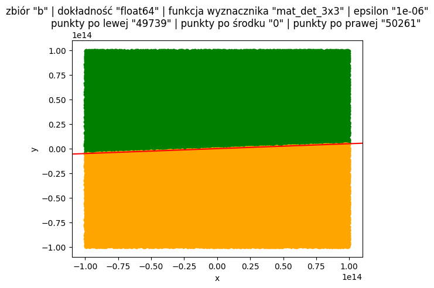

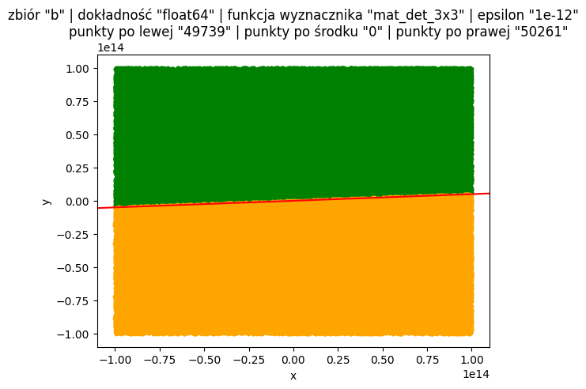

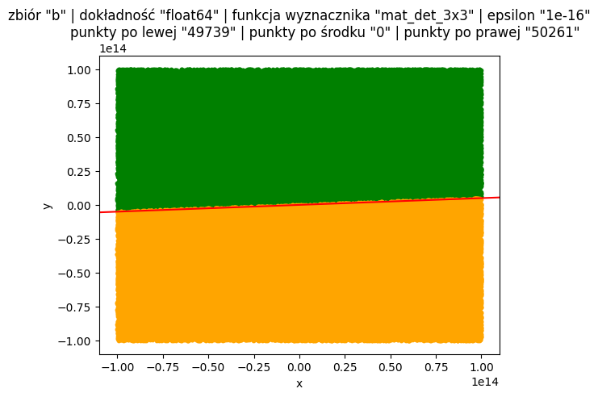

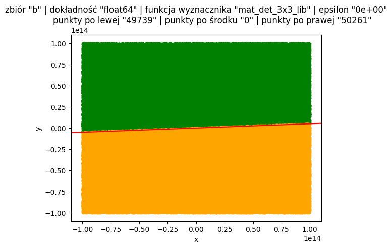

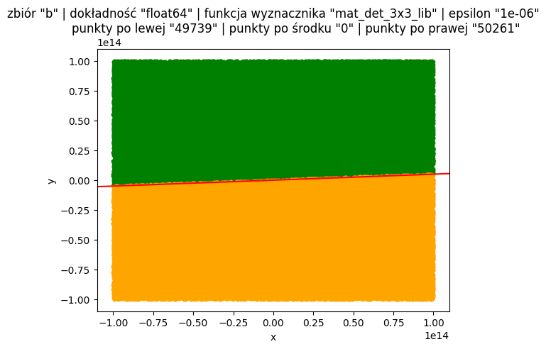

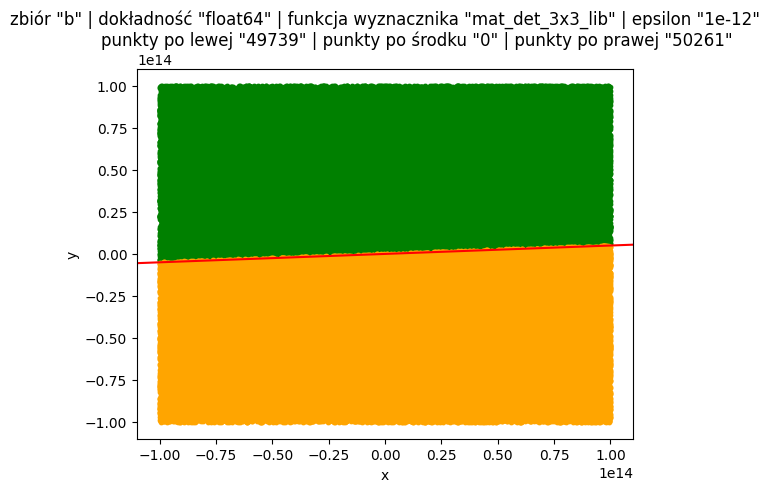

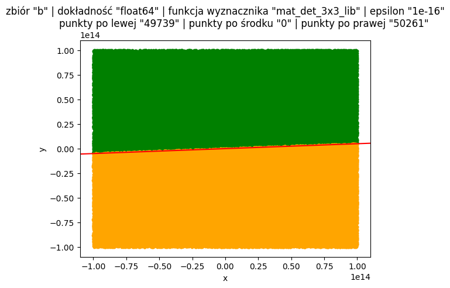

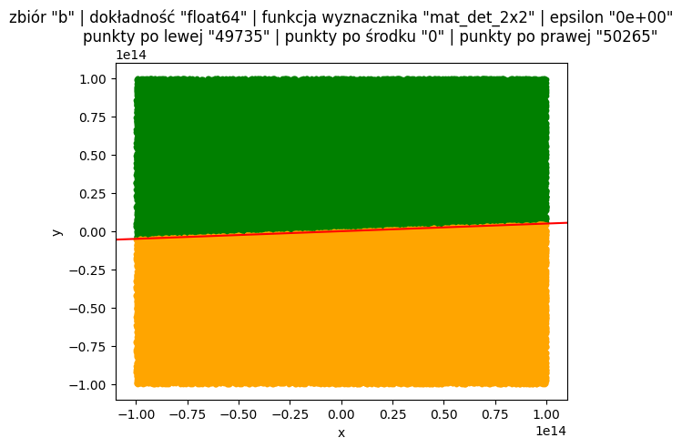

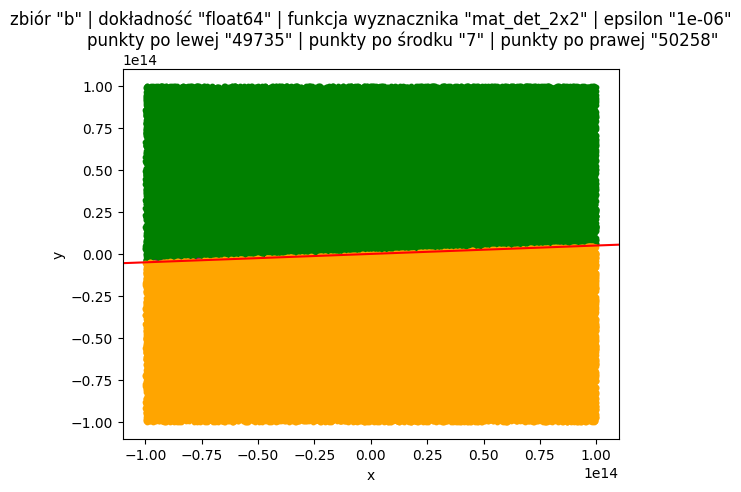

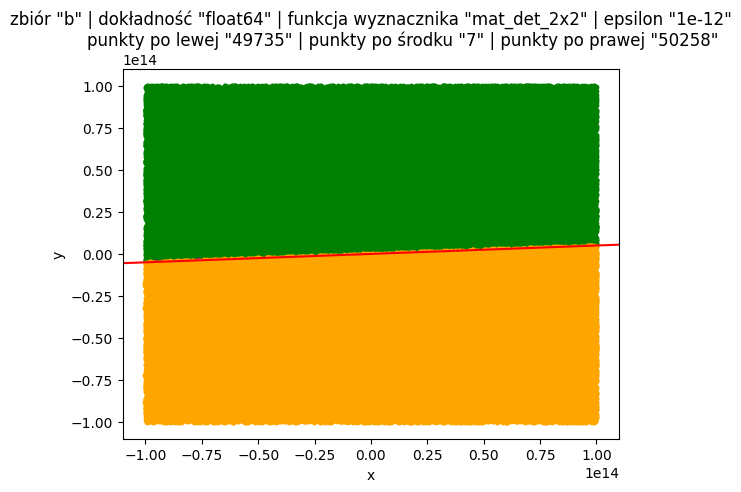

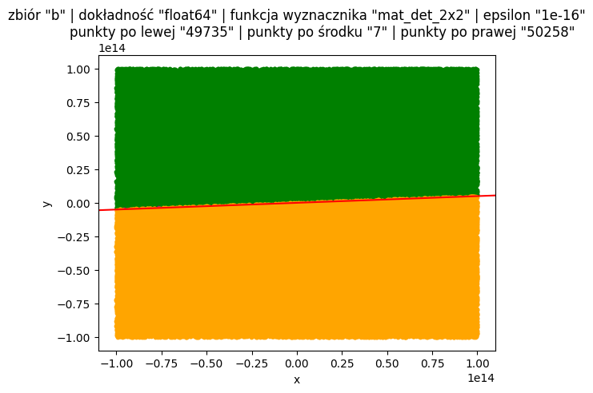

[20 more figures not shown]

```python
set_name = "b"
for float_resolution in float_resolutions:
    for mat_det_func in mat_det_funcs:
        for epsilon in epsilons:
            (
                classified_points_b_left,
                classified_points_b_mid,
                classified_points_b_right,
            ) = categorize_points(
                float_resolution(points_b), a, b, mat_det_func, epsilon
            )

            title = f"zbiór \"{set_name}\" | dokładność \"{float_resolution.__name__}\" | funkcja wyznacznika \"{mat_det_func.__name__}\" | epsilon \"{epsilon:.0e}\"\n\
            punkty po lewej \"{len(classified_points_b_left)}\" | punkty po środku \"{len(classified_points_b_mid)}\" | punkty po prawej \"{len(classified_points_b_right)}\""

            vis = draw_line(
                classified_points_b_left,
                classified_points_b_mid,
                classified_points_b_right,
                title=title
            )

            parameters = {
                "set_name": set_name,
                "float_resolution": float_resolution,
                "mat_det_func": mat_det_func,
                "epsilon": epsilon,
                "classified_points_left": classified_points_b_left,
                "classified_points_mid": classified_points_b_mid,
                "classified_points_right": classified_points_b_right,
                "visualiser": vis,
            }
            classification_results.append(parameters)
```